# GenomicHeatmaps Answers

Rockefeller University, Bioinformatics Resource Centre

https://rockefelleruniversity.github.io/

In this session we will review some CTCF ChIP-seq data from the Encode consortium datasets.

- Kindey CTCF peakcalls - [ENCFF784YSO](https://www.encodeproject.org/files/ENCFF784YSO/@@download/ENCFF784YSO.bed.gz)
- Lung CTCF peakcalls - [ENCFF116ZIX](https://www.encodeproject.org/files/ENCFF116ZIX/@@download/ENCFF116ZIX.bed.gz)
- Heart CTCF peakcalls - [ENCFF409RRE](https://www.encodeproject.org/files/ENCFF409RRE/@@download/ENCFF409RRE.bed.gz)
- Kindey CTCF BigWig - [ENCFF193CUU](https://www.encodeproject.org/files/ENCFF193CUU/@@download/ENCFF193CUU.bigWig)
- Lung CTCF BigWig - [ENCFF633LEJ](https://www.encodeproject.org/files/ENCFF633LEJ/@@download/ENCFF633LEJ.bigWig)
- Heart CTCF BigWig - [ENCFF688LXO](https://www.encodeproject.org/files/ENCFF688LXO/@@download/ENCFF688LXO.bigWig)

## **Exercise 1** - Download the bed files and create 1 non-redundant set of peaks for the Lung, Heart and Kidney samples. Write the set of peaks to a BED file.

```r
require(rtracklayer)
require(GenomicRanges)
beds <- dir(pattern="bed.gz")
bedsAsDF <- lapply(beds,read.delim,sep="\t",header=FALSE)
grangesOfBeds <- lapply(bedsAsDF,makeGRangesFromDataFrame,seqnames.field = "V1",start.field = "V2",end.field = "V3")
grangesListOfBeds <- GRangesList(grangesOfBeds)
nrSet <- resize(grangesListOfBeds,width = 1000,fix="center")
names(grangesListOfBeds) <- c("Lung","Heart","Kidney")
grangesListOfBeds
```

```
## GRangesList object of length 3:
## $Lung
## GRanges object with 64742 ranges and 0 metadata columns:
##           seqnames              ranges strand
##              <Rle>           <IRanges>  <Rle>
##       [1]    chr11   53317313-53317593      *
##       [2]     chr7   34746183-34746463      *
##       [3]     chr1 154103315-154103595      *
##       [4]     chr1 179799028-179799308      *
##       [5]    chr12   72732024-72732304      *
##       ...      ...                 ...    ...
##   [64738]     chr7 137478266-137478622      *
##   [64739]     chr2   32912428-32912796      *
##   [64740]     chr3   96580185-96580539      *
##   [64741]     chr8   70629724-70630132      *
##   [64742]     chr5 120102766-120103127      *
##   -------
##   seqinfo: 31 sequences from an unspecified genome; no seqlengths
##
## $Heart
## GRanges object with 44533 ranges and 0 metadata columns:
##           seqnames              ranges strand
##              <Rle>           <IRanges>  <Rle>
##       [1]    chr15   86261377-86261601      *
##       [2]     chr1   36580890-36581114      *
##       [3]    chr11   75510348-75510572      *
##       [4]     chr7 105400308-105400532      *
##       [5]    chr11   74408767-74408991      *
##       ...      ...                 ...    ...
##   [44529]    chr10   77130640-77130878      *
##   [44530]     chr6   90737496-90737712      *
##   [44531]     chr2   32912500-32912723      *
##   [44532]     chr3 122638720-122638954      *
##   [44533]     chr7 137478331-137478557      *
##   -------
##   seqinfo: 31 sequences from an unspecified genome; no seqlengths
##
## $Kidney
## GRanges object with 65482 ranges and 0 metadata columns:
##           seqnames              ranges strand
##              <Rle>           <IRanges>  <Rle>
##       [1]     chr7 116309784-116310114      *
##       [2]    chr11   95105506-95105836      *
##       [3]     chr4   98091490-98091820      *
##       [4]     chr7     4996229-4996559      *
##       [5]     chr1 133054622-133054952      *
##       ...      ...                 ...    ...
##   [65478]     chr1 181888785-181889231      *
##   [65479]     chr4 138319502-138319898      *
##   [65480]     chr2   32912430-32912817      *
##   [65481]     chr5 114667471-114667974      *
##   [65482]     chr8   70629657-70630155      *
##   -------
##   seqinfo: 31 sequences from an unspecified genome; no seqlengths
```

```r
nrSet <- reduce(unlist(grangesListOfBeds))
export.bed(nrSet,"nrCTCF.bed")
```

## **Exercise 2** - Create a vennDiagram of overlaps between Lung, heart and kidney peaks with out non-redundant set of peak.

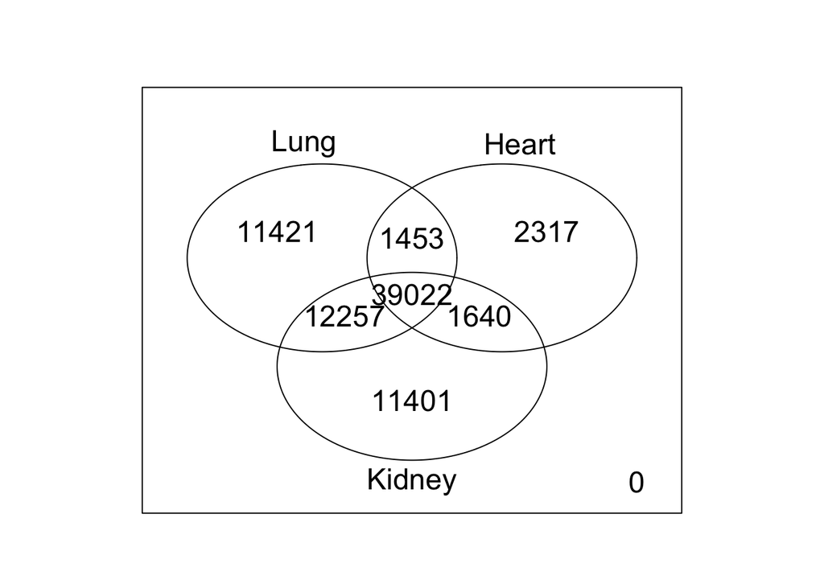

```r
nrSet <- reduce(unlist(grangesListOfBeds))
nrSet$Lung <- nrSet %over% grangesListOfBeds["Lung"]
nrSet$Heart <- nrSet %over% grangesListOfBeds["Heart"]
nrSet$Kidney <- nrSet %over% grangesListOfBeds["Kidney"]

require(limma)
vennDiagram(mcols(nrSet))
```

```r
export.bed(nrSet[nrSet$Lung & !nrSet$Heart & !nrSet$Kidney,],con="LungSpecific_CTCF.bed")
export.bed(nrSet[!nrSet$Lung & nrSet$Heart & !nrSet$Kidney,],con="HeartSpecific_CTCF.bed")
export.bed(nrSet[!nrSet$Lung & !nrSet$Heart & nrSet$Kidney,],con="KidneySpecific_CTCF.bed")
export.bed(nrSet[nrSet$Lung & nrSet$Heart & nrSet$Kidney,],con="Common_CTCF.bed")

LungSpecific <- nrSet[nrSet$Lung & !nrSet$Heart & !nrSet$Kidney,]
heartSpecific <- nrSet[!nrSet$Lung & nrSet$Heart & !nrSet$Kidney,]
kidneySpecific <- nrSet[!nrSet$Lung & !nrSet$Heart & nrSet$Kidney,]
common <- nrSet[nrSet$Lung & nrSet$Heart & nrSet$Kidney,]
```

## **Exercise 4** - Sample 2000 peaks from the non-reduced set of peaks and write to a new bed.

```r
nrSet <- nrSet[sample(1:length(nrSet),2000),]
export.bed(nrSet,"nrCTCF.bed")
```

**Exercise 5** With the new sampled BED file, produce a heatmap of signal over peaks

```r
require(profileplyr)
bigWigs <- dir(pattern = "bigWig")
ctcf_profile <- BamBigwig_to_chipProfile(bigWigs,
                                   testRanges = "nrCTCF.bed",
                                   style = "point",
                                   format = "bigwig",
                                   distanceAround = 400)
```

```
## Loading bigwig files.
```

```
## Making ChIPprofile object from signal files.
```

[output not shown]

[output cut: 38 more lines]

[output not shown]

```r
ctcf_profile <- as_profileplyr(ctcf_profile)
ctcf_profile
```

```
## class: profileplyr
## dim: 2000 40
## metadata(0):
## assays(3): ENCFF193CUU.bigWig ENCFF633LEJ.bigWig ENCFF688LXO.bigWig
## rownames(2000): giID767 giID768 ... giID1565 giID1566
## rowData names(5): name score sgGroup giID names
## colnames: NULL
## colData names(0):
```

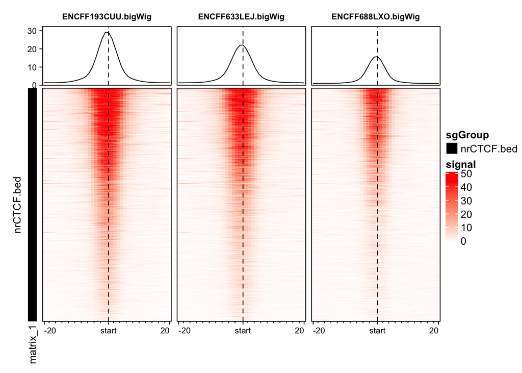

```r
generateEnrichedHeatmap(ctcf_profile)
```

**Exercise 5** Provide more sensible sample names and colour the heatmaps by tissue.

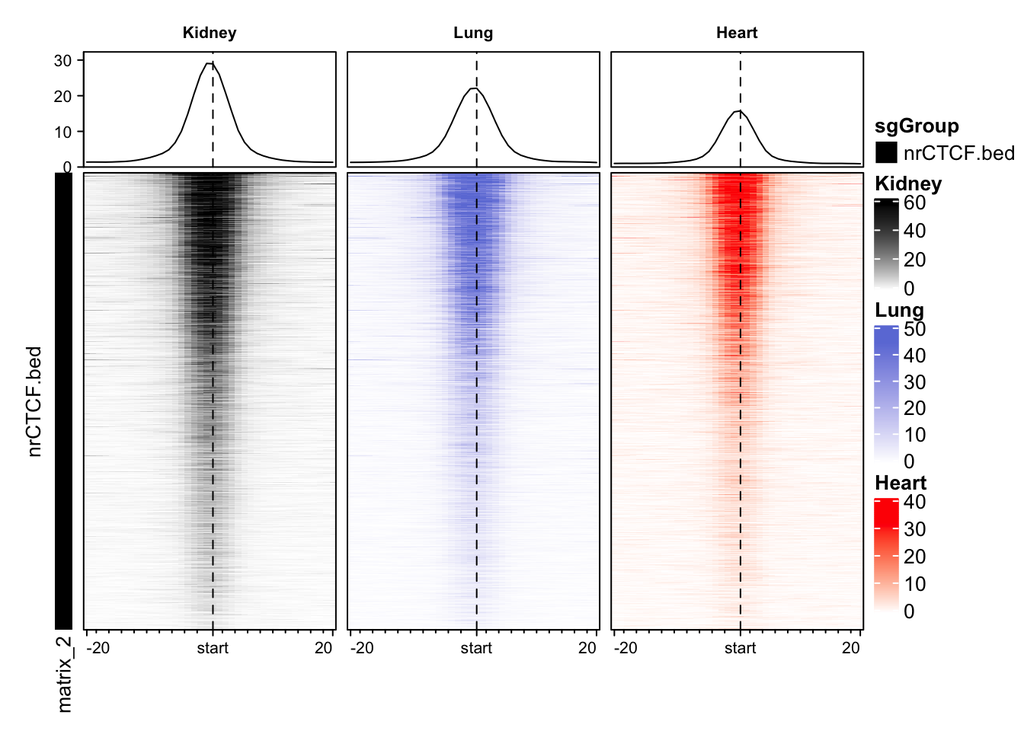

```r
rownames(sampleData(ctcf_profile)) <- c("Kidney","Lung","Heart")
sampleData(ctcf_profile)$Tissue <- c("Kidney","Lung","Heart")
generateEnrichedHeatmap(ctcf_profile,color_by_sample_group = "Tissue")
```

```r
ctcf_profile <- clusterRanges(ctcf_profile,kmeans_k = 6)
```

```
## K means clustering used.
```

```
## A column has been added to the range metadata with the column name 'cluster', and the 'rowGroupsInUse' has been set to this column.
```

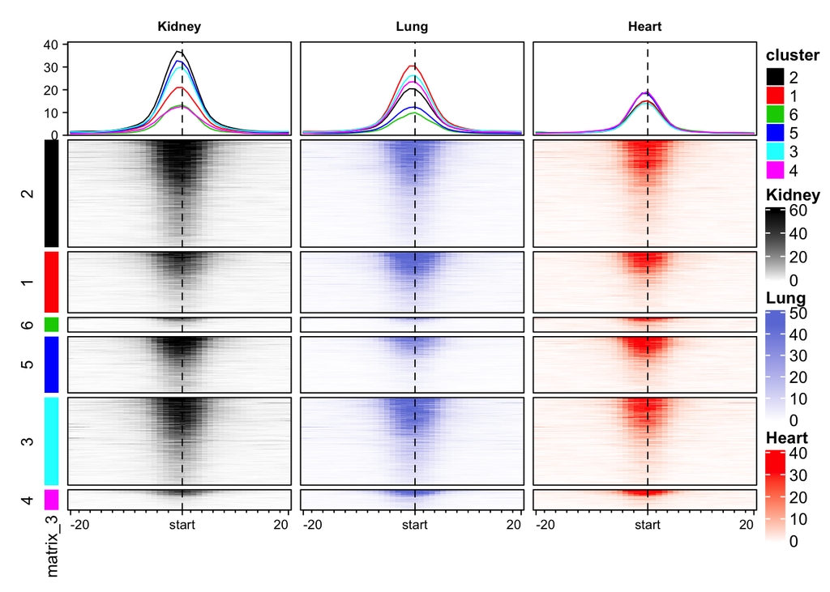

```r
generateEnrichedHeatmap(ctcf_profile,color_by_sample_group = "Tissue")
```

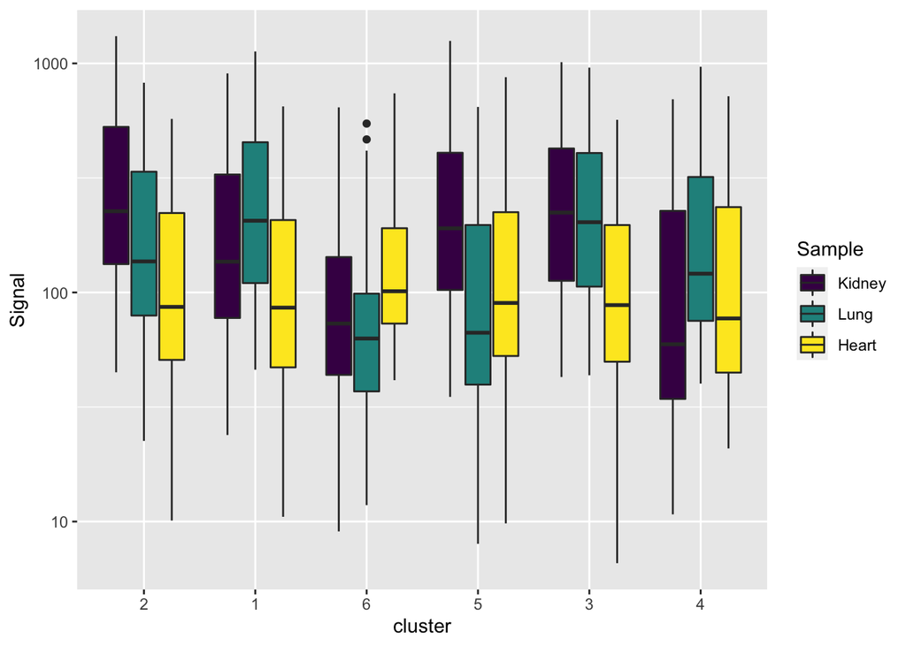

```r
toPlot <- summarize(ctcf_profile,output = "long",fun="rowSums",sampleData_columns_for_longPlot = "Tissue")
require(ggplot2)
ggplot(toPlot,aes(x=cluster,y=Signal,fill=Sample))+geom_boxplot()+scale_y_log10()
```

**Exercise 7** Annotate the clusters using Rgreat and write annotated cluster 5 to a data.frame.

```r
ctcf_profile <- annotateRanges_great(ctcf_profile,
                                              species = "mm10")
```

[figure not shown]

```r
peakGRanges <- rowRanges(ctcf_profile)

toWrite <- as.data.frame(peakGRanges[peakGRanges$cluster == 5],row.names = NULL)

write.table(toWrite,file="Cluster5.txt",sep="\t",row.names = FALSE)
```

```r
ctcf_profile <- groupBy(ctcf_profile,group = GRangesList(KidneySpecific,common))
generateEnrichedHeatmap(ctcf_profile)
```

[output not shown]

**Exercise 12**

```r
generateEnrichedHeatmap(ctcf_profile)
```

[output not shown]